# hw6

Alexis Maldonado

10/8/2023

1.a Since in part 2 we made a model that too in to account both genders and in part 3 we created 2 models divioding the data set to take account for each gender the predictors are going to have different influences between part and part 3 leading to a difference in estimated value.

1.b fit_females: Yhat = -4515.22 + 246.92*age + 241.32*bmi fit_males: Yhat = -4515.22 - 3497.572 + (246.919 + -8.287)*age + (241.32+168.55)*bmi

```r
insurance = read.csv("/Users/alexrubio/Downloads/Ds 303/insurance.csv")
insurance$gender = as.factor(insurance$gender)
insurance$region = as.factor(insurance$region)
insurance$smoker = as.factor(insurance$smoker)
fit =  lm ( charges ~ age + bmi + gender + age*gender + bmi*gender, data = insurance)
```

1.c To see if an interaction term is beneficial in the model you could run both models one with an interaction term and one with out one and compare both models with AIC/BIC since they are different lengths .

```r
regfit = regsubsets(charges ~ age + bmi + gender,data=insurance,nbest=1,nvmax=3)
regfit.sum = summary(regfit)
regfit.sum
```

```
## Subset selection object
## Call: regsubsets.formula(charges ~ age + bmi + gender, data = insurance,
##     nbest = 1, nvmax = 3)
## 3 Variables  (and intercept)
##            Forced in Forced out
## age            FALSE      FALSE
## bmi            FALSE      FALSE
## gendermale     FALSE      FALSE
## 1 subsets of each size up to 3
## Selection Algorithm: exhaustive
##          age bmi gendermale
## 1  ( 1 ) "*" " " " "
## 2  ( 1 ) "*" "*" " "
## 3  ( 1 ) "*" "*" "*"
```

```r
regfit1 = regsubsets(charges ~ age + bmi + gender + age*gender + bmi*gender,data=insurance, nbest = 1, nvmax = 5)
regfit.sum1 = summary(regfit1)
regfit.sum1
```

```
## Subset selection object
## Call: regsubsets.formula(charges ~ age + bmi + gender + age * gender +
##     bmi * gender, data = insurance, nbest = 1, nvmax = 5)
## 5 Variables  (and intercept)
##                Forced in Forced out
## age                FALSE      FALSE
## bmi                FALSE      FALSE
## gendermale         FALSE      FALSE
## age:gendermale     FALSE      FALSE
## bmi:gendermale     FALSE      FALSE
## 1 subsets of each size up to 5
## Selection Algorithm: exhaustive
##          age bmi gendermale age:gendermale bmi:gendermale
## 1  ( 1 ) "*" " " " "        " "            " "
## 2  ( 1 ) "*" "*" " "        " "            " "
## 3  ( 1 ) "*" "*" " "        " "            "*"
## 4  ( 1 ) "*" "*" "*"        " "            "*"
## 5  ( 1 ) "*" "*" "*"        "*"            "*"
```

```r
n = dim(insurance)[1]
p = rowSums(regfit.sum$which)
p1 = rowSums(regfit.sum1$which)


rss = regfit.sum$rss
AIC = n*log(rss/n) + 2*(p)
BIC = n*log(rss/n) + (p)*log(n)
rss1 = regfit.sum1$rss
AIC1 = n*log(rss1/n) + 2*(p1)
BIC1 = n*log(rss1/n) + (p1)*log(n)
AIC
```

```
##        1        2        3
## 25036.87 24997.42 24994.75
```

```r
AIC1
```

```
##        1        2        3        4        5
## 25036.87 24997.42 24993.48 24994.08 24996.05
```

```r
BIC
```

```
##        1        2        3
## 25047.27 25013.02 25015.55
```

```r
BIC1
```

```
##        1        2        3        4        5
## 25047.27 25013.02 25014.27 25020.08 25027.24
```

2.a yes, based on what we learned in class multicollinearity can make our data harder to correctly give significance towards an independent variable that is highly correlated to with another other.

2.b

```r
set.seed(42)
x1 = runif(100)
x2 = 0.8*x1 + rnorm(100,0,0.1)

beta0 = 3
beta1 = 2
beta2 = 4

error = rnorm(100, 0, 2)
Y = beta0 + beta1 * x1 + beta2 * x2 + error
cor(x1, x2)
```

```
## [1] 0.9404249
```

2.c

```r
train_index = sample(1:100, 0.8 * 100)
train = data.frame(Y = Y[train_index], x1 = x1[train_index], x2 = x2[train_index])
test = data.frame(Y = Y[-train_index], x1 = x1[-train_index], x2 = x2[-train_index])

model = lm(Y ~ x1+x2, data = train)


yhat = predict(model, newdata = test)
mse = mean((yhat - test$Y)^2)
mse
```

```
## [1] 3.632236
```

2.d

```r
mse_values = numeric(2500)
for (i in 1:2500) {
    Y = beta0 + beta1 * x1 + beta2 * x2 + error
    train_index = sample(1:100, 0.8 * 100)
    train = data.frame(Y = Y[train_index], x1 = x1[train_index], x2 = x2[train_index])
    test = data.frame(Y = Y[-train_index], x1 = x1[-train_index], x2 = x2[-train_index])
    model = lm(Y ~ x1 + x2, data = train)
    yhat = predict(model, newdata = test)
    mse_values[i] = mean((yhat - test$Y)^2)
}
mean(mse_values)
```

```
## [1] 3.691048
```

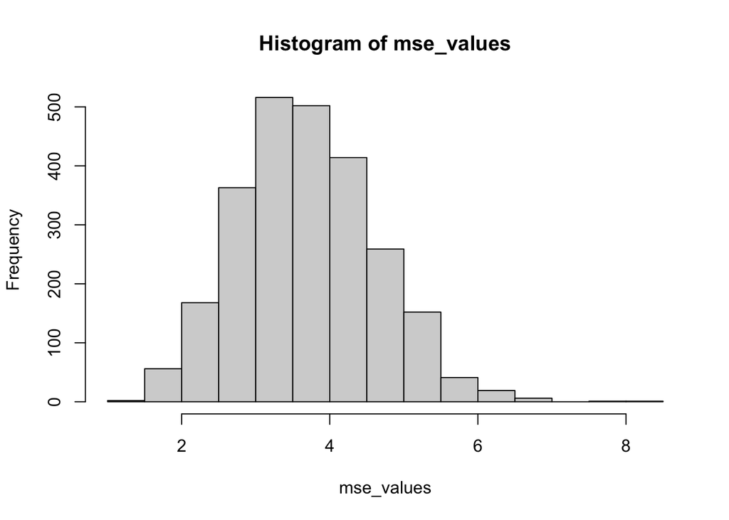

```r
hist(mse_values)
```

2.e

```r
set.seed(24)
x1 = runif(100)
x2 = rnorm(100,0,1)

beta0 = 3
beta1 = 2
beta2 = 4

error = rnorm(100, 0, 2)
Y2 = beta0 + beta1 * x1 + beta2 * x2 + error
cor(x1, x2)
```

```
## [1] 0.03316596
```

2.f

```r
mse_values2 = numeric(2500)
for (i in 1:2500) {
    Y2 = beta0 + beta1 * x1 + beta2 * x2 + error
    train_i = sample(1:100, 0.8 * 100)
    train2 = data.frame(Y2 = Y2[train_i], x1 = x1[train_i], x2 = x2[train_i])
    test2 = data.frame(Y2 = Y2[-train_i], x1 = x1[-train_i], x2 = x2[-train_i])
    model2 = lm(Y2 ~ x1 + x2, data = train2)
    yhat2 = predict(model2, newdata = test2)
    mse_values2[i] = mean((yhat2 - test2$Y2)^2)
}
mean(mse_values2)
```

```
## [1] 4.082694
```

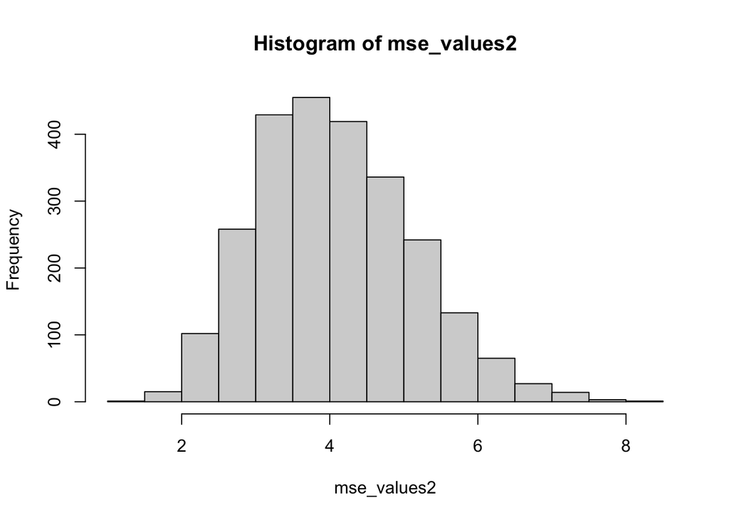

```r
hist(mse_values2)
```

2.g With the results from these two models we can infer that multicollinearity is not a problem over all since both mse’s were very similar.

3.a

```r
set.seed(12)
x = model.matrix(Apps~.,data= College)[,-1]
Y = College$Apps

grid = 10^seq(10,-2,length=100)
```

3.b

```r
college_train = sample(1:nrow(x), nrow(x)/2)
college_test=(-college_train)
Y.test = Y[college_test]
```

3.c

```r
rmodel = cv.glmnet(x[college_train,],Y[college_train],alpha = 0, lambda = grid, nfolds =5)
bestl = rmodel$lambda.min
bestl
```

```
## [1] 4.641589
```

3.d

```r
coefl = coef(rmodel, s = bestl)[-1]
l2 = sqrt(sum(coefl^2))
l2
```

```
## [1] 539.2139
```

3.e

```r
yhat = predict(rmodel, s = bestl,newx = x[college_test,])
mean((yhat-Y.test)^2)
```

```
## [1] 1431803
```

3.f

```r
lmodel = cv.glmnet(x[college_train,],Y[college_train],alpha = 1, lambda = grid, nfolds =5)
bestl2 = lmodel$lambda.min
bestl2
```

```
## [1] 14.17474
```

3.g

```r
coefl2 = coef(lmodel, s = bestl2)[-1]
l1 = sum(coefl2^2)
l1
```

```
## [1] 296580.2
```

3.h

```r
yhat1 = predict(lmodel, s = bestl2, newx = x[college_test,])
mean((yhat1 -Y.test)^2)
```

```
## [1] 1484667
```

3.i Between the two there is not too big of a difference, ridge was smaller by only a bit which make sense. OVer all however the mse is very high so we can assume this model still needs more work since it is not able to predict acccurately